# Lecture 1

Introduction

Sara Martino

sara.martino@ntnu.no

Dept. of Mathematical Science, NTNU

Janine Illian

Janine.Illian@glasgow.ac.uk

University of Glasgow

Jafet Belmont

Jafet.Belmont@glasgow.ac.uk

University of Glasgow

## Outline

- What are INLA and `inlabru`?
- Why the Bayesian framework?
- Which model are `inlabru`-friendly?
- What are Latent Gaussian Models?
- How are they implemented in `inlabru`?

## What is INLA? What is `inlabru`?

**The short answer:**

> INLA is a fast method to do Bayesian inference with latent Gaussian models and `inlabru` is an `R`-package that implements this method with a flexible and simple interface.

**The (much) longer answer:**

- Rue, H., Martino, S. and Chopin, N. (2009), Approximate Bayesian inference for latent Gaussian models by using integrated nested Laplace approximations. *Journal of the Royal Statistical Society: Series B (Statistical Methodology)*, 71: 319-392.
- Van Niekerk, J., Krainski, E., Rustand, D., & Rue, H. (2023). A new avenue for Bayesian inference with INLA. *Computational Statistics & Data Analysis*, 181, 107692.
- Lindgren, F., Bachl, F., Illian, J., Suen, M. H., Rue, H., & Seaton, A. E. (2024). inlabru: software for fitting latent Gaussian models with non-linear predictors. *arXiv preprint* arXiv:2407.00791.
- Lindgren, F., Bolin, D., & Rue, H. (2022). The SPDE approach for Gaussian and non-Gaussian fields: 10 years and still running. *Spatial Statistics*, 50, 100599.

## Where?

**Website-tutorials**

`inlabru` https://inlabru-org.github.io/inlabru/

`R-INLA` https://www.r-inla.org/home

**Discussion forums**

`inlabru` https://github.com/inlabru-org/inlabru/discussions

`R-INLA` https://groups.google.com/g/r-inla-discussion-group

**Books**

- Blangiardo, M., & Cameletti, M. (2015). Spatial and spatio-temporal Bayesian models with R-INLA. John Wiley & Sons.
- Gómez-Rubio, V. (2020). Bayesian inference with INLA. Chapman and Hall/CRC.
- Krainski, E., Gómez-Rubio, V., Bakka, H., Lenzi, A., Castro-Camilo, D., Simpson, D., … & Rue, H. (2018). Advanced spatial modeling with stochastic partial differential equations using R and INLA. Chapman and Hall/CRC.
- Wang, X., Yue, Y. R., & Faraway, J. J. (2018). Bayesian regression modeling with INLA. Chapman and Hall/CRC.

## So… Why should you use `inlabru`?

- What type of problems can we solve?
- What type of models can we use?
- When can we use it?

## So… Why should you use `inlabru`?

- What type of problems can we solve?
- What type of models can we use?
- When can we use it `inlabru’?

> To properly answer these questions, we need to start at the very beginning…

## The core

- We have observed something.

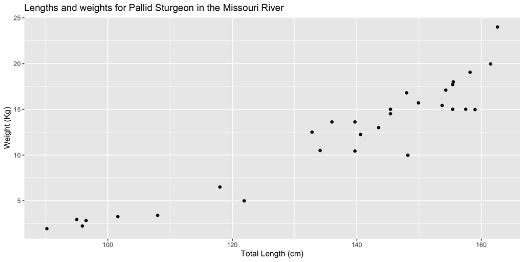

## The core

- We have observed something.
- We have questions.

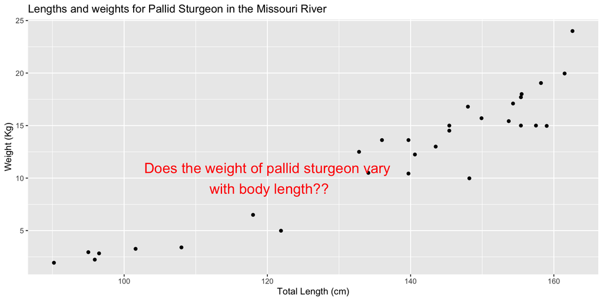

## The core

- We have observed something.
- We have questions.
- We want answers!

## How do we find answers?

We need to make choices:

> - Bayesian or frequentist?
> - How do we model the data?
> - How do we compute the answer?

## How do we find answers?

We need to make choices:

- Bayesian or frequentist?
- How do we model the data?
- How do we compute the answer?

These questions are **not** independent.

## Bayesian or frequentist?

In this course we embrace the Bayesian perspective

- There are no “*true but unknown*” parameters!

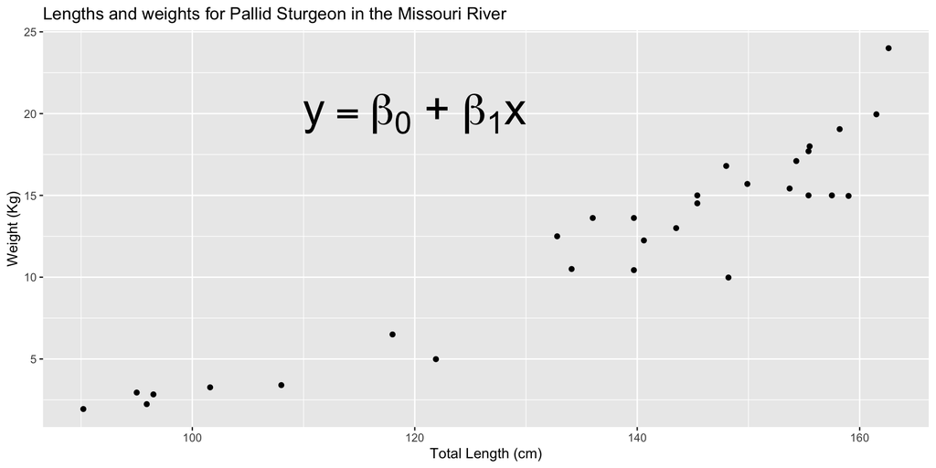

## Bayesian or frequentist?

In this course we embrace the Bayesian perspective

- There are no “*true but unknown*” parameters!
- Every parameter is described by a probability distribution!

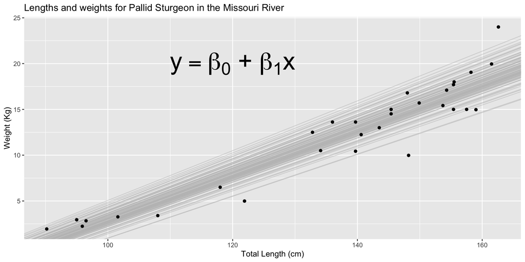

## Bayesian or frequentist?

In this course we embrace the Bayesian perspective

- There are no “*true but unknown*” parameters!
- Every parameter is described by a probability distribution!
- Evidence from the data is used to update the beliefs we had before observing the data!

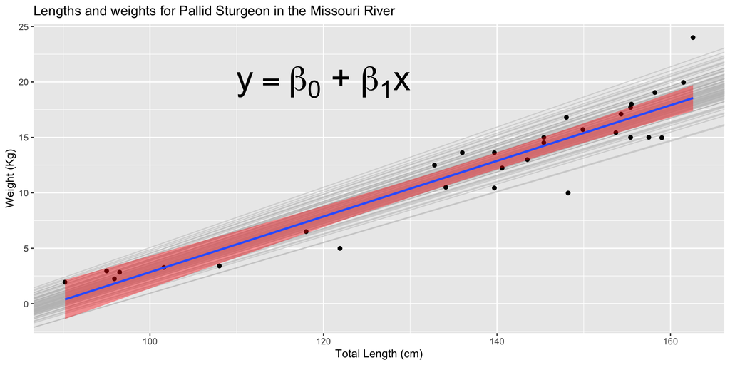

## Some more details I

We define as the `linear predictor` the mean (or a function of the mean) of our observations `given` the model components.

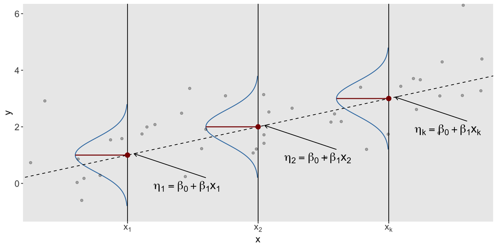

In this case $E(y_i|\beta_0, \beta_i) = \eta_i = \beta_0 + \beta_1 x_i$

## Some more details I

We define as the **linear predictor** the mean (or a function of the mean) of our observations **given** the model components.

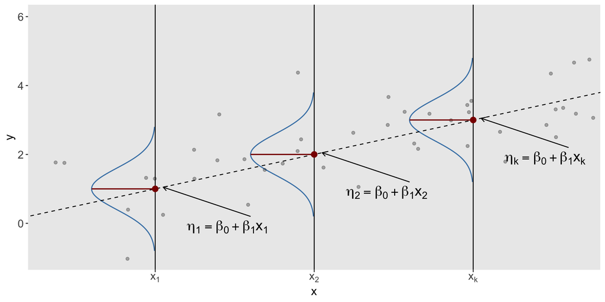

In this case $E(y_i|\beta_0, \beta_i) =\eta_i = \color{red}{\boxed{\beta_0}} + \color{red}{\boxed{\beta_1 x_i}}$

This model has two components!

## Some more details II

Given the **linear predictor** $\eta$ the observations are independent of each other!

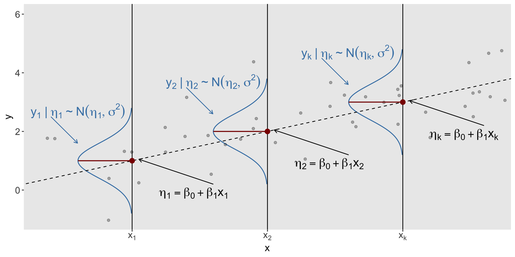

This means that **all dependencies** in the observations are accounted for by the components!

## Some more details II

Given the **linear predictor** $\eta$ the observations are independent of each other!

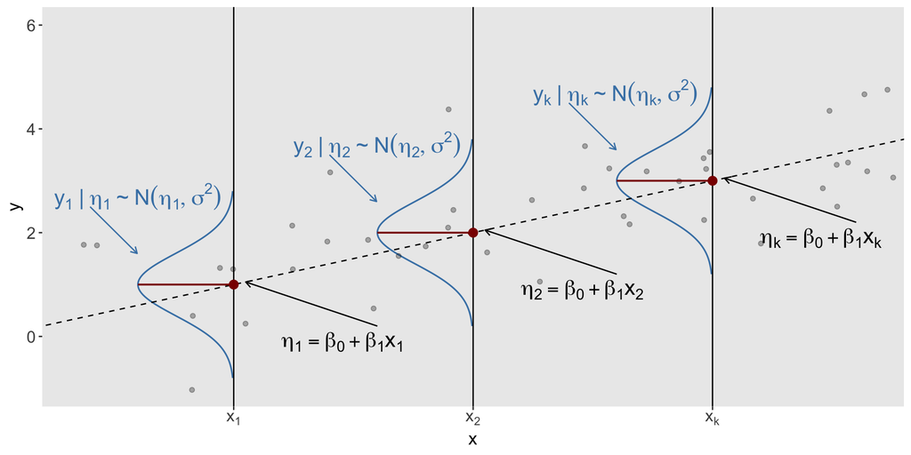

The observation model (likelihood) can be written as:

$$\pi(\mathbf{y}|\eta,\sigma^2) = \prod_{i = 1}^n\pi(y_i|\eta_i,\sigma^2)$$

## Let’s formalize this a bit…

The elements of an `inlabru`-friendly statistical model are:

1. The observational model
   $$\begin{aligned}
   y_i|\eta_i, \sigma^2 & \sim\mathcal{N}(\eta_i,\sigma^2),\qquad i = 1,\dots,n\\
   E(y_i|\eta_i, \sigma^2) & = \eta_i
   \end{aligned}$$
   **Note**: We assume that, given the *linear predictor* $\eta$, the data are independent of each other! Data dependence is expressed through the *components* of the linear predictor.

## Let’s formalize this a bit…

The elements of an `inlabru`-friendly statistical model are:

1. The observational model $y_i|\eta_i,\sigma^2\sim\mathcal{N}(\eta_i,\sigma^2),\qquad i = 1,\dots,n$
2. A model for the *linear predictor*
   $$E(y_i|\eta_i,\sigma^2) = \eta_i = \beta_0 + \beta_1x_i$$

## Let’s formalize this a bit…

The elements of an `inlabru` friendly statistical model are:

1. The observational model $y_i|\eta_i,\sigma^2\sim\mathcal{N}(\eta_i,\sigma^2),\qquad i = 1,\dots,n$
2. A model for the *linear predictor*

$$E(y_i|\eta_i,\sigma^2) = \eta_i = \color{red}{\boxed{\beta_0}} + \color{red}{\boxed{\beta_1x_i} }$$

**Note 1:** These are the *components* of our model! These explain the *dependence structure* of the data.

## Let’s formalize this a bit…

The elements of an `inlabru` friendly statistical model are:

1. The observational model $y_i|\eta_i,\sigma^2\sim\mathcal{N}(\eta_i,\sigma^2),\qquad i = 1,\dots,n$
2. A model for the *linear predictor* $\eta_i = \color{red}{\boxed{\beta_0}} + \color{red}{\boxed{\beta_1x_i} }$
3. A prior for the model components $\textbf{u}$
   $$\mathbf{u} = \{\beta_0, \beta_1\}\sim\mathcal{N}(0,\mathbf{Q}^{-1})$$
   **Note:** These always have a Gaussian prior and are used to explain the dependencies among observations!

## Let’s formalize this a bit…

The elements of an `inlabru` friendly statistical model are:

1. The observational model $y_i|\eta_i,\sigma^2\sim\mathcal{N}(\eta_i,\sigma^2),\qquad i = 1,\dots,n$
2. A model for the *linear predictor* $\eta_i = \color{red}{\boxed{\beta_0}} + \color{red}{\boxed{\beta_1x_i} }$
3. A prior for the model components $\mathbf{u} = \{\beta_0, \beta_1\}\sim\mathcal{N}(0,\mathbf{Q}^{-1})$
4. A prior for the non-Gaussian parameters $\theta$
   $$\theta = \sigma^2$$

## Latent Gaussian Models (LGM)

1. The observation model:
   $$\pi(\mathbf{y}|\eta,\theta) = \prod_{i=1}^{n}\pi(y_i|\eta_i,\theta)$$
2. Linear predictor $\eta_i = \beta_0 + \beta_1 x_i$
3. Latent Gaussian field $\pi(\mathbf{u}|\theta)$
4. The hyperparameters: $\pi(\theta)$
- **Stage 1** The data generating process

## Latent Gaussian Models (LGM)

1. The observation model:
   $$\pi(\mathbf{y}|\eta,\theta) = \prod_{i=1}^{n}\pi(y_i|\eta_i,\theta)$$
2. Linear predictor $\eta_i = \beta_0 + \beta_1 x_i$
3. Latent Gaussian field $\pi(\mathbf{u}|\theta)$
4. The hyperparameters: $\pi(\theta)$
- **Stage 1** The data generating process
- **Stage 2** The dependence structure

## Latent Gaussian Models (LGM)

1. The observation model:
   $$\pi(\mathbf{y}|\eta,\theta) = \prod_{i=1}^{n}\pi(y_i|\eta_i,\theta)$$
2. Linear predictor $\eta_i = \beta_0 + \beta_1 x_i$
3. Latent Gaussian field $\pi(\mathbf{u}|\theta)$
4. The hyperparameters: $\pi(\theta)$
- **Stage 1** The data generating process
- **Stage 2** The dependence structure
- **Stage 3** The hyperparameters

## Latent Gaussian Models (LGM)

1. The observation model:
   $$\pi(\mathbf{y}|\eta,\theta) = \prod_{i=1}^{n}\pi(y_i|\eta_i,\theta)$$
2. Linear predictor $\eta_i = \beta_0 + \beta_1 x_i$
3. Latent Gaussian field $\pi(\mathbf{u}|\theta)$
4. The hyperparameters: $\pi(\theta)$
- **Stage 1** The data generating process
- **Stage 2** The dependence structure
- **Stage 3** The hyperparameters

**Q**: What are we interested in?

## The posterior distribution

[figure not shown]

$$\color{red}{\pi(\mathbf{u},\theta|\mathbf{y})}\propto \color{blue}{\pi(\mathbf{y}|\mathbf{u},\theta)}\color{green}{\pi(\mathbf{u}|\theta)\pi(\theta)}$$

## The posterior distribution

[figure not shown]

## `inlabru` for linear regression

**The Model**
$$\begin{aligned}
y_i|\eta_i, \sigma^2 & \sim \mathcal{N}(\eta_i,\sigma^2)\\
\eta_i & = \beta_0 + \beta_i x_i
\end{aligned}$$

```r
library(inlabru)
Pallid[1:3,c("w","tl")]
```

```
      w    tl
1 2.239  95.9
2 2.948  95.0
3 3.402 108.0
```

**The code**

```r
# define the model components
cmp =  ~ -1 + beta0(1) + beta1(tl, model = "linear")

# define the model predictor
eta = w ~ beta0 + beta1

# build the observation model
lik = bru_obs(formula = eta,
              family = "gaussian",
              data = Pallid)

# fit the model
fit = bru(cmp, lik)
```

## `inlabru` for linear regression

**The Model**
$$\begin{aligned}
y_i|\eta_i, \sigma^2 & \sim \mathcal{N}(\eta_i,\sigma^2)\\
\eta_i & = \color{red}{\boxed{\beta_0}} + \color{red}{\boxed{\beta_i x_i}}
\end{aligned}$$

```r
Pallid[1:3,c("w","tl")]
```

```
      w    tl
1 2.239  95.9
2 2.948  95.0
3 3.402 108.0
```

**The code**

```r
# define model components
cmp =  ~ -1 + beta0(1) + beta1(tl, model = "linear")

# define model predictor
eta = w ~ beta0 + beta1

# build the observation model
lik = bru_obs(formula = eta,
              family = "gaussian",
              data = Pallid)

# fit the model
fit = bru(cmp, lik)
```

## `inlabru` for linear regression

**The Model**
$$\begin{aligned}
y_i|\eta_i, \sigma^2 & \sim \mathcal{N}(\eta_i,\sigma^2)\\
\eta_i & = \color{red}{\boxed{\beta_0 + \beta_i x_i}}
\end{aligned}$$

```r
library(inlabru)
Pallid[1:3,c("w","tl")]
```

```
      w    tl
1 2.239  95.9
2 2.948  95.0
3 3.402 108.0
```

**The code**

```r
# define model components
cmp =  ~ -1 + beta0(1) + beta1(tl, model = "linear")

# define model predictor
eta = w ~ beta0 + beta1

# build the observation model
lik = bru_obs(formula = eta,
              family = "gaussian",
              data = Pallid)

# fit the model
fit = bru(cmp, lik)
```

## `inlabru` for linear regression

**The Model**
$$\begin{aligned}
\color{red}{\boxed{y_i|\eta_i, \sigma^2}} & \color{red}{\boxed{\sim \mathcal{N}(\eta_i,\sigma^2)}}\\
\eta_i & = \beta_0 + \beta_i x_i
\end{aligned}$$

```r
library(inlabru)
Pallid[1:3,c("w","tl")]
```

```
      w    tl
1 2.239  95.9
2 2.948  95.0
3 3.402 108.0
```

**The code**

```r
# define model components
cmp =  ~ -1 + beta0(1) + beta1(tl, model = "linear")

# define model predictor
eta = w ~ beta0 + beta1

# build the observation model
lik = bru_obs(formula = eta,
              family = "gaussian",
              data = Pallid)

# fit the model
fit = bru(cmp, lik)
```

## `inlabru` for linear regression

**The Model**
$$\begin{aligned}
y_i|\eta_i, \sigma^2 & \sim \mathcal{N}(\eta_i,\sigma^2)\\
\eta_i & = \beta_0 + \beta_i x_i
\end{aligned}$$

```r
library(inlabru)
Pallid[1:3,c("w","tl")]
```

```
      w    tl
1 2.239  95.9
2 2.948  95.0
3 3.402 108.0
```

**The code**

```r
# define model components
cmp =  ~ -1 + beta0(1) + beta1(tl, model = "linear")

# define model predictor
eta = w ~ beta0 + beta1

# build the observation model
lik = bru_obs(formula = eta,
              family = "gaussian",
              data = Pallid)

# fit the model
fit = bru(cmp, lik)
```

## `inlabru` for linear regression

[figure not shown]

## Real datasets are more complicated!

Data can have several dependence structures: temporal, spatial,…

**Using a Bayesian framework** we will:

- build (hierarchical) models to account for potentially complicated dependency structures in the data.
- attribute uncertainty to model parameters and latent variables using priors.

**Two main challenges**:

- We need computationally efficient methods to calculate posteriors (this is where INLA helps!).
- We select priors in a sensible way (we’ll talk about these later)

## The good news!!

In many cases complicated spatio-temporal models are *just* special cases of the same model structure!! 😃

- **Stage 1**: What is the distribution of the responses?
- **Stage 2**: What are the model components? And what is their distribution?
- **Stage 3**: What are our prior beliefs about the parameters controlling the components in the model?

## The good news!!

In many cases complicated spatio-temporal models are *just* special cases of the same model structure!! 😃

- **Stage 1**: What is the distribution of the responses?
  - Gaussian response? (temperature, rainfall, fish weight …)
  - Count data? (people infected with a disease in each area)
  - Point pattern? (locations of trees in a forest)
  - Binary data? (yes/no response, binary image)
  - Survival data? (recovery time, time to death)
  - … (many more examples!!)
- **Stage 2**: What are the model components? and what is their distribution?
- **Stage 3**: What are our prior beliefs about the parameters controlling the components in the model?

## The good news!!

In many cases complicated spatio-temporal models are *just* special cases of the same model structure!! 😃

- **Stage 1**: What is the distribution of the responses?
  - We assume data to be *conditionally* independent given the model components and some hyperparameters
  - This means that all dependencies in data are explained in Stage 2.
- **Stage 2**: What are the model components? and what is their distribution?
- **Stage 3**: What are our prior beliefs about the parameters controlling the components in the model?

## The good news!!

In many cases complicated spatio-temporal models are *just* special cases of the same model structure!! 😃

- **Stage 1**: What is the distribution of the responses?
- **Stage 2**: What are the model components? and what is their distribution?

Here we can have:

- Fixed effects for covariates
- Unstructured random effects (individual effects, group effects)
- Structured random effects (AR(1), regional effects, )
- …

These are linked to the responses in the likelihood through *linear predictors*.

- **Stage 3**: What are our prior beliefs about the parameters controlling the components in the model?

## The good news!!

In many cases complicated spatio-temporal models are *just* special cases of the same model structure!! 😃

- **Stage 1**: What is the distribution of the responses?
- **Stage 2**: What are the model components? and what is their distribution?
- **Stage 3**: What are our prior beliefs about the parameters controlling the components in the model?

  The likelihood and the latent model typically have hyperparameters that control their behaviour.

  These can include:
  - Variance of observation noise
  - Dispersion parameter in the negative binomial model
  - Variance of unstructured effects
  - …

## The second good news!

No matter how complicated your model is, the `inlabru` workflow is *always* the same 😃

```r
# Define model components
comps <- component_1(...) +
  component_2(...) + ...

# Define the model predictor
pred <- linear_function(component_1,
                            component_2, ...)

# Build the observation model
lik <- bru_obs(formula = pred,
               family = ... ,
               data = ... ,
                ...)

# Fit the model
fit <- bru(comps, lik, ...)
```

## The second good news!

No matter how complicated your model is, the `inlabru` workflow is *always* the same 😃

```r
# Define model components
comps <- component_1(...) +
  component_2(...) + ...

# Define the model predictor
pred <- linear_function(component_1,
                            component_2, ...)

# Build the observation model
lik <- bru_obs(formula = pred,
               family = ... ,
               data = ... ,
                ...)

# Fit the model
fit <- bru(comps, lik, ...)
```

**NOTE** we will see later that this function can also be non-linear… 😁

# Examples

## The Tokyo rainfall data

One example with time series: Rainfall over 1 mm in the Tokyo area for each calendar day during two years (1983-84)

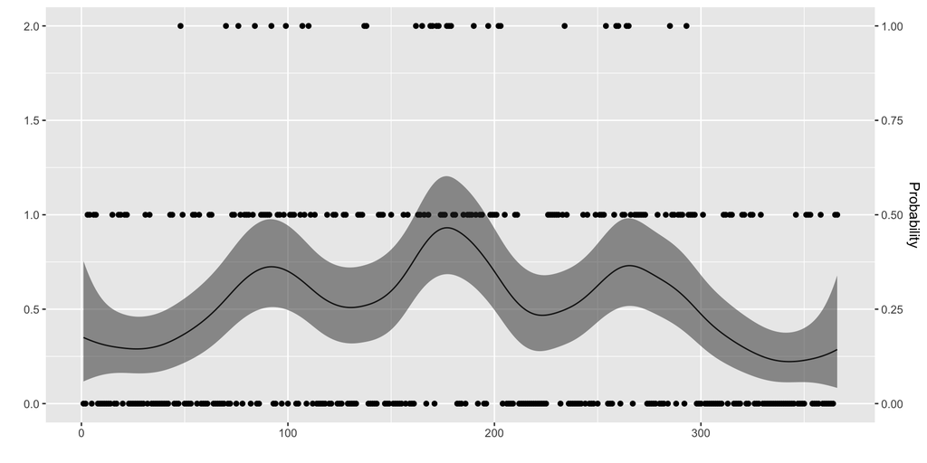

## The model

**Stage 1** The observation model

$$y_t|\eta_t\sim\text{Bin}(n_t, p_t),\qquad \eta_t = \text{logit}(p_t),\qquad i = 1,\dots,366$$
$$n_t = \left\{
\begin{array}{lr}
1, & \text{for}\; 29\; \text{February}\\
2, & \text{other days}
\end{array}\right.$$
$$y_t =
\begin{cases}
\{0,1\}, & \text{for}\; 29\; \text{February}\\
\{0,1,2\}, & \text{other days}
\end{cases}$$

- the likelihood has no hyperparameters

## The model

**Stage 1** The observation model

$$y_t|\eta_t\sim\text{Bin}(n_t, p_t),\qquad \eta_t = \text{logit}(p_t),\qquad i = 1,\dots,366$$

**Stage 2** The latent field
$$\eta_t = \beta_0 + f(\text{time}_t)$$

- probability of rain depends on the day of the year $t$
- $\beta_0$ is an intercept
- $f(\text{time}_t)$ is a RW2 model (this is just a smoother). The smoothness is controlled by a hyperparameter $\tau_f$

## The model

**Stage 1** The observation model

$$y_t|\eta_t\sim\text{Bin}(n_t, p_t),\qquad \eta_t = \text{logit}(p_t),\qquad i = 1,\dots,366$$

**Stage 2** The latent field
$$\eta_t = \beta_0 + f(\text{time}_t)$$

**Stage 3** The hyperparameters

- The structured time effect is controlled by one parameter $\tau_f$.
- We assign a prior to $\tau_f$ to finalize the model.

## `inlabru` for time series

**The Model**

$$\begin{aligned}
y_t|\eta_t & \sim \text{Binomial}(n_t,p_t)\\
\text{logit}(p_t) = \eta_i & = \color{red}{\boxed{\beta_0}} + \color{red}{\boxed{f(\text{time}_t)}}
\end{aligned}$$

```r
Tokyo[1:3,]
```

```
  y n time
1 0 2    1
2 0 2    2
3 1 2    3
```

**The code**

```r
# define model component
cmp =  ~ -1 + beta0(1) + time_effect(time, model = "rw2", cyclic = TRUE)

# define model predictor
eta = y ~ beta0 + time_effect

# build the observation model
lik = bru_obs(formula = eta,
              family = "binomial",
              Ntrials = n,
              data = Tokyo)

# fit the model
fit = bru(cmp, lik)
```

## `inlabru` for time series

**The Model**

$$\begin{aligned}
y_t|\eta_t & \sim \text{Binomial}(n_t,p_t)\\
\text{logit}(p_t) = \color{red}{\boxed{\eta_i}} & = \color{red}{\boxed{\beta_0 + f(\text{time}_t)}}
\end{aligned}$$

```r
Tokyo[1:3,]
```

```
  y n time
1 0 2    1
2 0 2    2
3 1 2    3
```

**The code**

```r
# define model component
cmp =  ~ -1 + beta0(1) + time_effect(time, model = "rw2", cyclic = TRUE)

# define model predictor
eta = y ~ beta0 + time_effect

# build the observation model
lik = bru_obs(formula = eta,
              family = "binomial",
              Ntrials = n,
              data = Tokyo)

# fit the model
fit = bru(cmp, lik)
```